# Загрузка и первое знакомство с данными

Для начала можно попробовать оставить выбросы (возможно есть смысл их сохранить, но в ради приличия сделаем несколько выборок: в одной проведем winsorization, а другой оставим с выбросами)

Теперь интересно есть ли какие-то зависимости в данных (посмотрим как влияют атрибуты на таргет-переменную + посмотрим на корреляцию между атрибутами и таргет-переменной)

```
Зависимость quality от fixed acidity
```

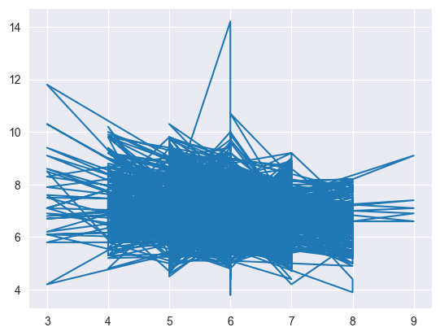

```
Зависимость quality от volatile acidity
```

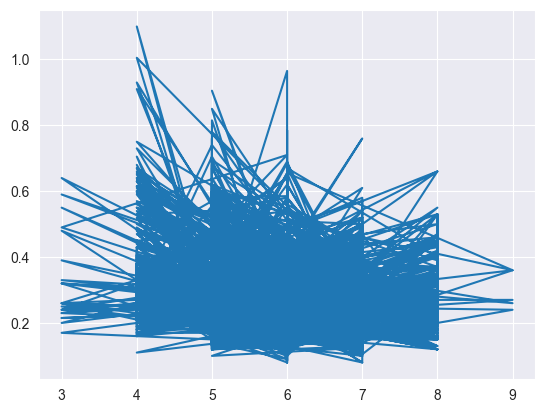

```
Зависимость quality от citric acid
```

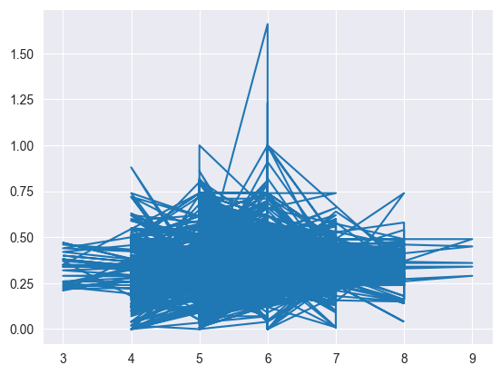

```
Зависимость quality от residual sugar
```

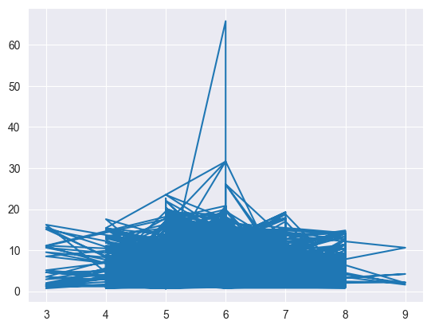

```
Зависимость quality от chlorides
```

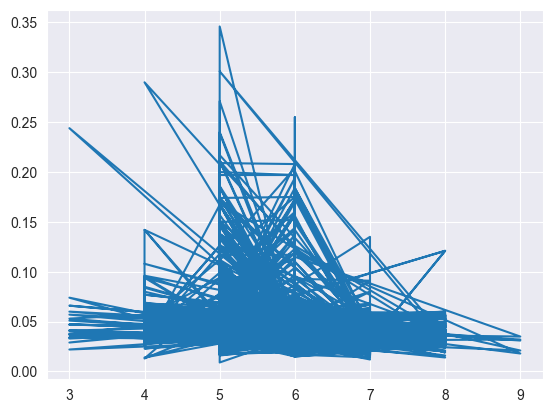

```
Зависимость quality от free sulfur dioxide
```

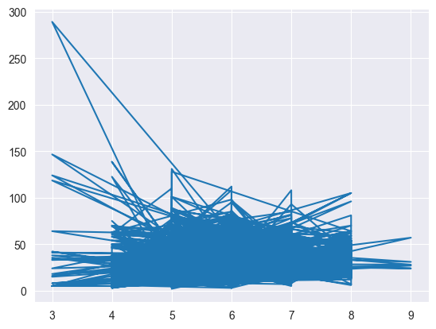

```
Зависимость quality от total sulfur dioxide
```

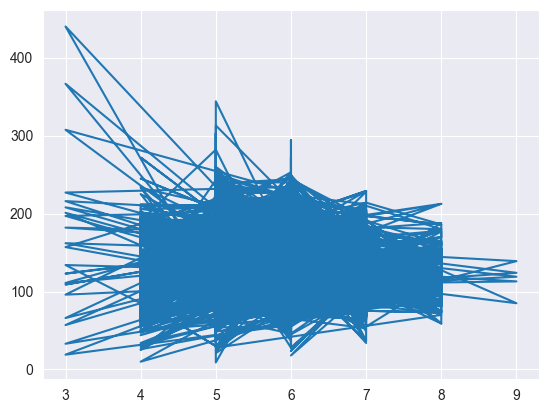

```
Зависимость quality от density
```

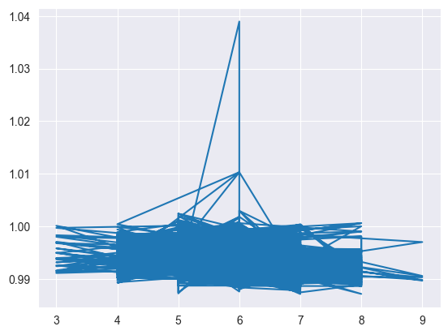

```
Зависимость quality от pH
```

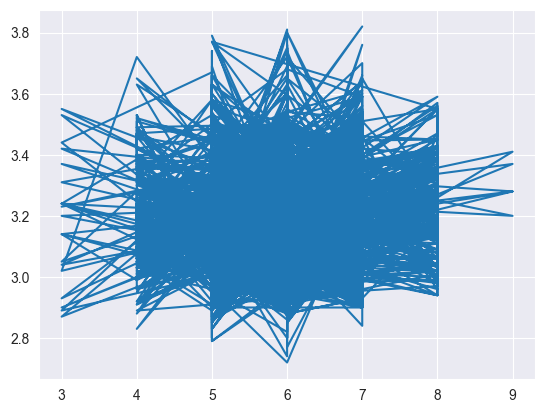

```
Зависимость quality от sulphates
```

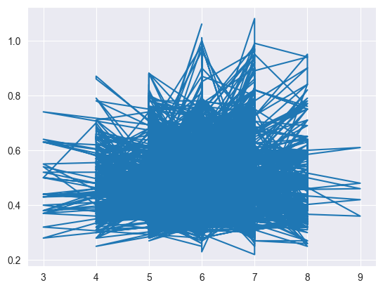

```
Зависимость quality от alcohol
```

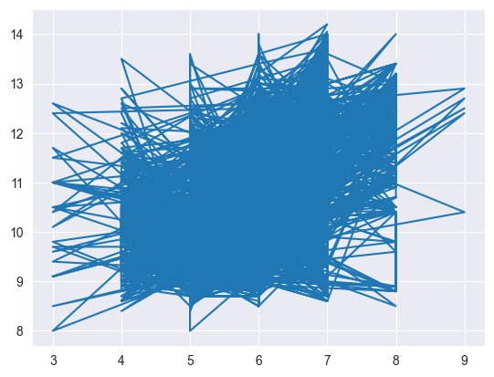

```
Зависимость quality от quality
```

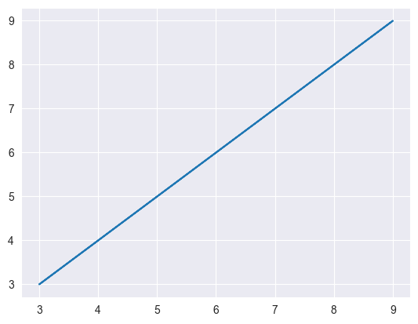

```python
# Сначала посмотрим на график зависимости таргет переменной от атрибутов
for column in white_wines.columns[:-1]:
    print(f'Зависимость quality от {column}')
    plt.plot(white_wines['quality'], white_wines[column])
    plt.show()
```

Как можно заметить, ярковыраженной зависимости тут нигде не встречается (то есть ни один атрибут не имеет какого-то прямого влияния на таргет-переменную)

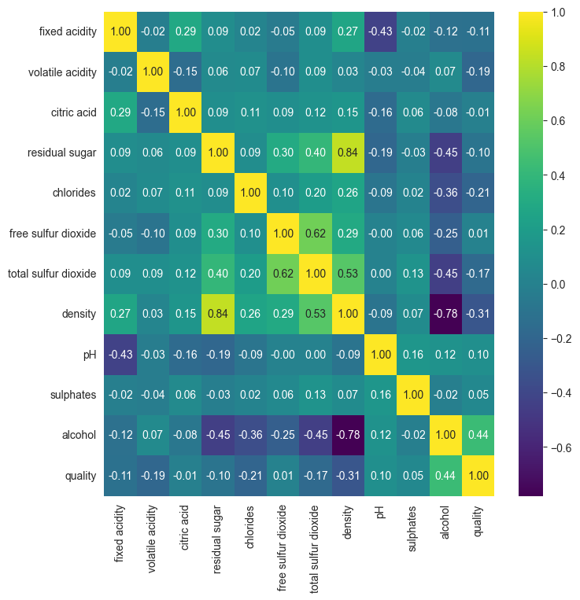

```python
# Теперь давайте построим график корреляции
corr = white_wines.corr()

figsize = (8, 8)
fig, ax = plt.subplots(figsize=figsize)
sns.heatmap(corr, annot=True, cmap='viridis', fmt=".2f")
plt.show()
```

Здесь уже поинтереснее, можно увидеть, что, например, спирт и плотность наиболее сильно влияют на показатель качества (при этом стоит отметить, что спирт имеет самую высокую положительную корреляцию, а вот плотность самую высокую отрицательную кореляцию)

Для чего нам эта информация?

- Во-первых, мы можем увидеть, что некоторые атрибуты имеют крайне низкую корреляцию с таргет-переменной (например, сульфаты, лимонная кислота, свободный диоксид серы..). Если наша модель будет показывать низкие результаты, мы сможем, например, убрать данные арибуты, чтобы они не мешали модели обучаться - **не отвлекали ее**
- Во-вторых, мы можем наглядно увидеть, какие корряции и зависимости есть в данных (это может пригодится на этапах feature engineering если нужно будет изменять датасет (возможно дополнять новыми **фичами**) в связи с низкими показателями точности модели)

# Подготовка данных

```python
# Для начала соединим два дадатасета красного и белого вин (превратим их в категории)
white_wines['wine type'] = 'white'
red_wines['wine type'] = 'red'
```

```python
all_wines = pd.concat([white_wines, red_wines], axis=0)
all_wines = all_wines.reset_index(drop=True)
```

```python
all_wines
```

|  | fixed acidity | volatile acidity | citric acid | residual sugar | chlorides | free sulfur dioxide | total sulfur dioxide | density | pH | sulphates | alcohol | quality | wine type |
| --- | --- | --- | --- | --- | --- | --- | --- | --- | --- | --- | --- | --- | --- |
| 0 | 7.0 | 0.270 | 0.36 | 20.7 | 0.045 | 45.0 | 170.0 | 1.00100 | 3.00 | 0.45 | 8.8 | 6 | white |
| 1 | 6.3 | 0.300 | 0.34 | 1.6 | 0.049 | 14.0 | 132.0 | 0.99400 | 3.30 | 0.49 | 9.5 | 6 | white |
| 2 | 8.1 | 0.280 | 0.40 | 6.9 | 0.050 | 30.0 | 97.0 | 0.99510 | 3.26 | 0.44 | 10.1 | 6 | white |
| 3 | 7.2 | 0.230 | 0.32 | 8.5 | 0.058 | 47.0 | 186.0 | 0.99560 | 3.19 | 0.40 | 9.9 | 6 | white |
| 4 | 7.2 | 0.230 | 0.32 | 8.5 | 0.058 | 47.0 | 186.0 | 0.99560 | 3.19 | 0.40 | 9.9 | 6 | white |
| ... | ... | ... | ... | ... | ... | ... | ... | ... | ... | ... | ... | ... | ... |
| 6492 | 6.2 | 0.600 | 0.08 | 2.0 | 0.090 | 32.0 | 44.0 | 0.99490 | 3.45 | 0.58 | 10.5 | 5 | red |
| 6493 | 5.9 | 0.550 | 0.10 | 2.2 | 0.062 | 39.0 | 51.0 | 0.99512 | 3.52 | 0.76 | 11.2 | 6 | red |
| 6494 | 6.3 | 0.510 | 0.13 | 2.3 | 0.076 | 29.0 | 40.0 | 0.99574 | 3.42 | 0.75 | 11.0 | 6 | red |
| 6495 | 5.9 | 0.645 | 0.12 | 2.0 | 0.075 | 32.0 | 44.0 | 0.99547 | 3.57 | 0.71 | 10.2 | 5 | red |
| 6496 | 6.0 | 0.310 | 0.47 | 3.6 | 0.067 | 18.0 | 42.0 | 0.99549 | 3.39 | 0.66 | 11.0 | 6 | red |

6497 rows × 13 columns

```python
# Теперь применим OneHotEncoding для правильной обработки наших категорий
from sklearn.preprocessing import OneHotEncoder

encoder = OneHotEncoder()
encoded_wines = encoder.fit_transform(all_wines[['wine type']])

encoded_wines = pd.DataFrame(
    encoded_wines.toarray(),
    columns=encoder.get_feature_names_out()
)

encoded_all_wines = pd.concat([
    all_wines.drop('wine type', axis=1),
    encoded_wines
], axis=1)

encoded_all_wines = encoded_all_wines[[
    'wine type_red', 'wine type_white', 'fixed acidity',
    'volatile acidity', 'citric acid', 'residual sugar',
    'chlorides', 'free sulfur dioxide', 'total sulfur dioxide',
    'density', 'pH', 'sulphates', 'alcohol', 'quality'
]]

encoded_all_wines
```

|  | wine type_red | wine type_white | fixed acidity | volatile acidity | citric acid | residual sugar | chlorides | free sulfur dioxide | total sulfur dioxide | density | pH | sulphates | alcohol | quality |
| --- | --- | --- | --- | --- | --- | --- | --- | --- | --- | --- | --- | --- | --- | --- |
| 0 | 0.0 | 1.0 | 7.0 | 0.270 | 0.36 | 20.7 | 0.045 | 45.0 | 170.0 | 1.00100 | 3.00 | 0.45 | 8.8 | 6 |
| 1 | 0.0 | 1.0 | 6.3 | 0.300 | 0.34 | 1.6 | 0.049 | 14.0 | 132.0 | 0.99400 | 3.30 | 0.49 | 9.5 | 6 |
| 2 | 0.0 | 1.0 | 8.1 | 0.280 | 0.40 | 6.9 | 0.050 | 30.0 | 97.0 | 0.99510 | 3.26 | 0.44 | 10.1 | 6 |
| 3 | 0.0 | 1.0 | 7.2 | 0.230 | 0.32 | 8.5 | 0.058 | 47.0 | 186.0 | 0.99560 | 3.19 | 0.40 | 9.9 | 6 |
| 4 | 0.0 | 1.0 | 7.2 | 0.230 | 0.32 | 8.5 | 0.058 | 47.0 | 186.0 | 0.99560 | 3.19 | 0.40 | 9.9 | 6 |
| ... | ... | ... | ... | ... | ... | ... | ... | ... | ... | ... | ... | ... | ... | ... |
| 6492 | 1.0 | 0.0 | 6.2 | 0.600 | 0.08 | 2.0 | 0.090 | 32.0 | 44.0 | 0.99490 | 3.45 | 0.58 | 10.5 | 5 |
| 6493 | 1.0 | 0.0 | 5.9 | 0.550 | 0.10 | 2.2 | 0.062 | 39.0 | 51.0 | 0.99512 | 3.52 | 0.76 | 11.2 | 6 |
| 6494 | 1.0 | 0.0 | 6.3 | 0.510 | 0.13 | 2.3 | 0.076 | 29.0 | 40.0 | 0.99574 | 3.42 | 0.75 | 11.0 | 6 |
| 6495 | 1.0 | 0.0 | 5.9 | 0.645 | 0.12 | 2.0 | 0.075 | 32.0 | 44.0 | 0.99547 | 3.57 | 0.71 | 10.2 | 5 |
| 6496 | 1.0 | 0.0 | 6.0 | 0.310 | 0.47 | 3.6 | 0.067 | 18.0 | 42.0 | 0.99549 | 3.39 | 0.66 | 11.0 | 6 |

6497 rows × 14 columns

```python
# Теперь нужно создать два типа наборов данных
columns = ['fixed acidity', 'volatile acidity', 'citric acid', 'residual sugar',
           'chlorides', 'free sulfur dioxide', 'total sulfur dioxide', 'density',
           'pH', 'sulphates', 'alcohol']

# В данном наборе мы проведем winsorization
import numpy as np
from scipy.stats.mstats import winsorize

final_wins_wines = encoded_all_wines.copy()
for column in columns:
    final_wins_wines[column] = winsorize(final_wins_wines[column], limits=(0.1, 0.1))

# В этом наборе данных мы не будем работать с выбросами и оставим все как есть
final_wthoutWins_wines = encoded_all_wines.copy()
```

```python
from sklearn.model_selection import train_test_split
from sklearn.preprocessing import StandardScaler

# Дальше разделим данные на тестовую и тренировочную выборки и стандартизируем данные
# винсоризированные данные
# разделение данных
wX = final_wins_wines.drop({'quality'}, axis=1)
wy = final_wins_wines['quality']

wX_train, wX_test, wy_train, wy_test = train_test_split(wX, wy, test_size=0.2, random_state=42)

# стандартизация данных
w_scaler = StandardScaler()
wX_train_scaled = w_scaler.fit_transform(wX_train)
wX_test_scaled = w_scaler.transform(wX_test)

print('Wins scaled data')
display(wX_train_scaled)
display(wX_test_scaled)

# невинсоризированные данные
# разделение данных
X = final_wthoutWins_wines.drop({'quality'}, axis=1)
y = final_wthoutWins_wines['quality']

X_train, X_test, y_train, y_test = train_test_split(X, y, test_size=0.2, random_state=42)

# стандартизация данных
scaler = StandardScaler()
X_train_scaled = scaler.fit_transform(X_train)
X_test_scaled = scaler.transform(X_test)

print('\n\nScaled data without wins')
display(X_train_scaled)
display(X_test_scaled)
```

```
Wins scaled data
```

```
array([[-0.57312868,  0.57312868, -0.60438813, ..., -1.04071546,
        -0.92705509, -1.18542432],
       [-0.57312868,  0.57312868,  1.5627269 , ..., -1.50409114,
        -1.37599239, -0.43523898],
       [-0.57312868,  0.57312868, -1.28874024, ..., -0.19119337,
        -1.28620493, -0.24769264],
       ...,
       [ 1.74480887, -1.74480887,  1.90490295, ..., -0.42288121,
         1.3176314 , -0.71655848],
       [ 1.74480887, -1.74480887,  1.90490295, ...,  0.81278729,
         1.7665687 ,  1.72154389],
       [-0.57312868,  0.57312868,  1.10649215, ...,  0.04049448,
         0.95848156, -0.06014631]], shape=(5197, 13))
```

```
array([[-0.57312868,  0.57312868, -0.14815339, ..., -0.42288121,
        -0.38833033,  1.34645122],
       [-0.57312868,  0.57312868,  0.53619873, ..., -1.11794474,
        -1.10663001,  0.31494637],
       [-0.57312868,  0.57312868, -1.06062287, ..., -0.73179833,
        -1.28620493, -1.27919749],
       ...,
       [ 1.74480887, -1.74480887,  0.87837478, ..., -1.34963258,
         1.7665687 , -1.18542432],
       [ 1.74480887, -1.74480887,  0.42214004, ...,  1.27616297,
         0.59933173,  0.2211732 ],
       [ 1.74480887, -1.74480887,  0.19402267, ...,  1.5850801 ,
         1.7665687 , -0.90410482]], shape=(1300, 13))
```

```
Scaled data without wins
```

```
array([[-0.57312868,  0.57312868, -0.47810509, ..., -0.86006706,
        -0.75122123, -1.08506915],
       [-0.57312868,  0.57312868,  0.97505476, ..., -1.60531829,
        -1.14846347, -0.41405807],
       [-0.57312868,  0.57312868, -0.93699767, ..., -0.17692009,
        -1.01604939, -0.24630531],
       ...,
       [ 1.74480887, -1.74480887,  4.72267752, ..., -0.3632329 ,
         0.90395477, -0.66568723],
       [ 1.74480887, -1.74480887,  1.28098315, ...,  0.63043542,
         2.4267167 ,  2.43773898],
       [-0.57312868,  0.57312868,  0.66912637, ...,  0.00939272,
         0.63912661, -0.07855254]], shape=(5197, 13))
```

```
array([[-0.57312868,  0.57312868, -0.1721767 , ..., -0.3632329 ,
        -0.35397899,  1.17959322],
       [-0.57312868,  0.57312868,  0.28671589, ..., -0.92217133,
        -0.88363531,  0.256953  ],
       [-0.57312868,  0.57312868, -0.78403347, ..., -0.61164998,
        -1.01604939, -1.16894553],
       ...,
       [ 1.74480887, -1.74480887,  0.51616218, ..., -1.10848414,
         3.61844342, -1.08506915],
       [ 1.74480887, -1.74480887,  0.21023379, ...,  1.00306103,
         0.37429845,  0.17307661],
       [ 1.74480887, -1.74480887,  0.05726959, ...,  1.87252081,
         1.30119701, -0.83343999]], shape=(1300, 13))
```

```python
# Винсоризированные данные
import torch
from torch.utils.data import DataLoader, TensorDataset
import numpy as np

# Подготовка тренировочных данных
# Получаем тензоры
wX_train_Tensor = torch.tensor(wX_train_scaled.values if hasattr(wX_train_scaled, 'values') else wX_train_scaled,
                               dtype=torch.float32)
wy_train_Tensor = torch.from_numpy(wy_train.values).long()

# формируем датасет, который потом превращается в даталоадер
w_train_dataset = TensorDataset(wX_train_Tensor, wy_train_Tensor)
w_train_dataloader = DataLoader(w_train_dataset, batch_size=32, shuffle=True)

# Подготовка тестовых данных
# Получаем тензоры
wX_test_Tensor = torch.tensor(wX_test_scaled.values if hasattr(wX_test_scaled, 'values') else wX_test_scaled,
                              dtype=torch.float32)
wy_test_Tensor = torch.from_numpy(wy_test.values).long()

# формируем датасет, который потом превращается в даталоадер
w_test_dataset = TensorDataset(wX_test_Tensor, wy_test_Tensor)
w_test_dataloader = DataLoader(w_test_dataset, batch_size=32, shuffle=True)
```

```python
# Оригинальные данные
import torch
from torch.utils.data import DataLoader, TensorDataset
import numpy as np

# Подготовка тренировочных данных
# Получаем тензоры
X_train_Tensor = torch.tensor(X_train_scaled.values if hasattr(X_train_scaled, 'values') else X_train_scaled,
                              dtype=torch.float32)
y_train_Tensor = torch.tensor(y_train.values, dtype=torch.float32)

# формируем датасет, который потом превращается в даталоадер
train_dataset = TensorDataset(X_train_Tensor, y_train_Tensor)
train_dataloader = DataLoader(train_dataset, batch_size=32, shuffle=True)

# Подготовка тестовых данных
# Получаем тензоры
X_test_Tensor = torch.tensor(X_test_scaled.values if hasattr(X_test_scaled, 'values') else X_test_scaled,
                             dtype=torch.float32)
y_test_Tensor = torch.tensor(y_test.values, dtype=torch.float32)

# формируем датасет, который потом превращается в даталоадер
test_dataset = TensorDataset(X_test_Tensor, y_test_Tensor)
test_dataloader = DataLoader(test_dataset, batch_size=32, shuffle=True)
```

Подготовили два датасета для наших нейросетей:

1. Винсоризированные данные
   - w_train_dataloader (для обучения модели)
   - w_test_dataloader (для проверки модели)
2. Оригинальные данные
   - train_dataloader (для обучения модели)
   - test_dataloader (для проверки модели)

# Создание первых нейросетей

Напишем базовую нейросеть для каждого набора данных и подберем лучшие параметры с помощью Optuna

```python
import torch
import torch.nn as nn
import torch.nn.functional as F


# Нейросеть для решения регрессионных задач
class WineRegressor(nn.Module):
    def __init__(self, input_size, hidden_sizes, dropout=0.3):
        super().__init__()
        layers = []
        sizes = [input_size] + hidden_sizes

        # Для каждого перехода sizes[i] в sizes[i+1]
        for i in range(len(sizes) - 1):
            # линейное преобразование
            layers.append(nn.Linear(sizes[i], sizes[i + 1]))
            # нормализация для ускорения и стабилизации обучения
            layers.append(nn.BatchNorm1d(sizes[i + 1]))
            # функция активации (в отличие от стандартной, такая версия снижает вероятность умирания нейронов)
            layers.append(nn.LeakyReLU(0.01))
            # регуляризация, которое борется с переобучением, не давая нейросети зацикливаться на определенных нейронах
            layers.append(nn.Dropout(dropout))

        # последний линейный слой для составления нужного выходного размера
        layers.append(nn.Linear(sizes[-1], 1))

        # сборка нейросети
        self.net = nn.Sequential(*layers)
        self._initialize_weights()

    def _initialize_weights(self):
        # инициализация для всех линейных слоев
        for m in self.modules():
            if isinstance(m, nn.Linear):
                nn.init.xavier_uniform_(m.weight)

                # обнуляет отклонение bias
                if m.bias is not None:
                    nn.init.zeros_(m.bias)

    def forward(self, x):
        return self.net(x).squeeze(-1)
```

```python
from sklearn.metrics import mean_absolute_error


# Оценка для регрессии
def evaluate_regression(model, val_loader):
    model.eval()
    predictions = []
    targets = []

    with torch.no_grad():
        for inputs, labels in val_loader:
            outputs = model(inputs)
            predictions.extend(outputs.cpu().numpy())
            targets.extend(labels.cpu().numpy())

    return mean_absolute_error(targets, predictions)
```

## Проверяем модель на винсоризированных данных

```python
import optuna


# В самом конце notebook есть информация о данной функцие с пояснением
def set_seed(seed=42):
    import random, numpy as np
    torch.manual_seed(seed)
    random.seed(seed)
    np.random.seed(seed)
    if torch.cuda.is_available():
        torch.cuda.manual_seed(seed)


def objective(trial):
    n_layers = trial.suggest_int('n_layers', 1, 4)
    hidden_units = []
    for i in range(n_layers):
        hidden_units.append(trial.suggest_categorical(f'n_units_{i}', [64, 128, 256, 512]))

    model = WineRegressor(
        input_size=input_size,
        hidden_sizes=hidden_units,
        dropout=trial.suggest_float('dropout', 0.1, 0.5)
    )

    optimizer = torch.optim.Adam(
        model.parameters(),
        lr=trial.suggest_float('lr', 1e-5, 1e-3, log=True),
        weight_decay=trial.suggest_float('weight_decay', 1e-6, 1e-3, log=True)
    )

    criterion = torch.nn.L1Loss()  # MAE
    model.train()

    for epoch in range(50):
        for inputs, labels in w_train_dataloader:
            optimizer.zero_grad()
            outputs = model(inputs)
            loss = criterion(outputs, labels)
            loss.backward()
            optimizer.step()

    val_mae = evaluate_regression(model, w_test_dataloader)
    return val_mae  # для MAE минимизируем
```

```python
print("Форма входных данных:", next(iter(w_train_dataloader))[0].shape)
```

```
Форма входных данных: torch.Size([32, 13])
```

```python
input_size = 13

set_seed()
study = optuna.create_study(direction='minimize')
study.optimize(objective, n_trials=50, timeout=3600)

print("Лучшие параметры:", study.best_params)
print("Лучшее значение метрики:", study.best_value)
```

```
[I 2025-07-16 15:42:37,874] A new study created in memory with name: no-name-44c34aab-a640-4b01-91bc-07db14620206
[I 2025-07-16 15:42:45,547] Trial 0 finished with value: 0.724287521472344 and parameters: {'n_layers': 1, 'n_units_0': 256, 'dropout': 0.43934520626799073, 'lr': 1.4625522205283562e-05, 'weight_decay': 2.476344159143438e-06}. Best is trial 0 with value: 0.724287521472344.
[I 2025-07-16 15:42:54,973] Trial 1 finished with value: 0.6271145637218769 and parameters: {'n_layers': 2, 'n_units_0': 256, 'n_units_1': 256, 'dropout': 0.24916816562494115, 'lr': 0.0001536066120543033, 'weight_decay': 9.06662265104046e-06}. Best is trial 1 with value: 0.6271145637218769.
[I 2025-07-16 15:43:06,685] Trial 2 finished with value: 1.4372678863085233 and parameters: {'n_layers': 4, 'n_units_0': 128, 'n_units_1': 256, 'n_units_2': 64, 'n_units_3': 512, 'dropout': 0.45239946741916837, 'lr': 1.027335647985763e-05, 'weight_decay': 5.723556785693367e-05}. Best is trial 1 with…
[I 2025-07-16 15:43:20,621] Trial 3 finished with value: 0.677779044187986 and parameters: {'n_layers': 4, 'n_units_0': 128, 'n_units_1': 64, 'n_units_2': 512, 'n_units_3': 256, 'dropout': 0.3650027265138472, 'lr': 0.0001728533185277576, 'weight_decay': 1.236212441633914e-05}. Best is trial 1 with v…
[I 2025-07-16 15:43:24,261] Trial 4 finished with value: 0.561870069870582 and parameters: {'n_layers': 1, 'n_units_0': 128, 'dropout': 0.42219585715958435, 'lr': 0.0002937807592539278, 'weight_decay': 8.356013299223052e-06}. Best is trial 4 with value: 0.561870069870582.
[I 2025-07-16 15:43:32,035] Trial 5 finished with value: 0.7196368204630338 and parameters: {'n_layers': 2, 'n_units_0': 128, 'n_units_1': 512, 'dropout': 0.2610374628600333, 'lr': 5.7862365794118644e-05, 'weight_decay': 8.118991619477956e-05}. Best is trial 4 with value: 0.561870069870582.
[I 2025-07-16 15:43:42,196] Trial 6 finished with value: 1.3893370289068956 and parameters: {'n_layers': 3, 'n_units_0': 128, 'n_units_1': 128, 'n_units_2': 512, 'dropout': 0.37151487837073255, 'lr': 1.897051639325787e-05, 'weight_decay': 7.380909862732824e-05}. Best is trial 4 with value: 0.5618700…
[I 2025-07-16 15:43:50,331] Trial 7 finished with value: 0.7481052642602187 and parameters: {'n_layers': 3, 'n_units_0': 128, 'n_units_1': 64, 'n_units_2': 256, 'dropout': 0.3069549608864143, 'lr': 0.00031811777761497776, 'weight_decay': 3.6453034191922005e-06}. Best is trial 4 with value: 0.5618700…
[I 2025-07-16 15:44:01,324] Trial 8 finished with value: 1.111630169428312 and parameters: {'n_layers': 4, 'n_units_0': 128, 'n_units_1': 64, 'n_units_2': 64, 'n_units_3': 512, 'dropout': 0.2595834348090388, 'lr': 1.3237269979213262e-05, 'weight_decay': 1.0636878048564919e-06}. Best is trial 4 with …
[I 2025-07-16 15:44:25,567] Trial 9 finished with value: 0.9065871284558222 and parameters: {'n_layers': 4, 'n_units_0': 128, 'n_units_1': 512, 'n_units_2': 512, 'n_units_3': 512, 'dropout': 0.27040710144767205, 'lr': 1.0784786765371855e-05, 'weight_decay': 5.949614465792822e-06}. Best is trial 4 wi…
[I 2025-07-16 15:44:29,012] Trial 10 finished with value: 0.5189241383625911 and parameters: {'n_layers': 1, 'n_units_0': 64, 'dropout': 0.12371236443704353, 'lr': 0.0009401330068306977, 'weight_decay': 0.0004673044835803366}. Best is trial 10 with value: 0.5189241383625911.
[I 2025-07-16 15:44:32,449] Trial 11 finished with value: 0.5133871962473943 and parameters: {'n_layers': 1, 'n_units_0': 64, 'dropout': 0.11760916222053495, 'lr': 0.0008505991899934082, 'weight_decay': 0.0009119188500470505}. Best is trial 11 with value: 0.5133871962473943.
[I 2025-07-16 15:44:35,881] Trial 12 finished with value: 0.5186071553597084 and parameters: {'n_layers': 1, 'n_units_0': 64, 'dropout': 0.10760052973094854, 'lr': 0.0009616078762734682, 'weight_decay': 0.0009615962808924336}. Best is trial 11 with value: 0.5133871962473943.
```

[output cut: 37 more lines]

```
Лучшие параметры: {'n_layers': 2, 'n_units_0': 256, 'n_units_1': 512, 'dropout': 0.10101813532222283, 'lr': 0.00043364489263105204, 'weight_decay': 0.00013069132005636772}
Лучшее значение метрики: 0.4923312447621272
```

## Проверяем модель на оригинальных данных

```python
def objective(trial):
    n_layers = trial.suggest_int('n_layers', 1, 4)
    hidden_units = []
    for i in range(n_layers):
        hidden_units.append(trial.suggest_categorical(f'n_units_{i}', [64, 128, 256, 512]))

    model = WineRegressor(
        input_size=input_size,
        hidden_sizes=hidden_units,
        dropout=trial.suggest_float('dropout', 0.1, 0.5)
    )

    optimizer = torch.optim.Adam(
        model.parameters(),
        lr=trial.suggest_float('lr', 1e-5, 1e-3, log=True),
        weight_decay=trial.suggest_float('weight_decay', 1e-6, 1e-3, log=True)
    )

    criterion = torch.nn.L1Loss()  # MAE
    model.train()

    for epoch in range(50):
        for inputs, labels in train_dataloader:
            optimizer.zero_grad()
            outputs = model(inputs)
            loss = criterion(outputs, labels)
            loss.backward()
            optimizer.step()

    val_mae = evaluate_regression(model, test_dataloader)
    return val_mae  # для MAE минимизируем
```

```python
print("Форма входных данных:", next(iter(train_dataloader))[0].shape)
```

```
Форма входных данных: torch.Size([32, 13])
```

```python
input_size = 13

set_seed()
study = optuna.create_study(direction='minimize')
study.optimize(objective, n_trials=50, timeout=3600)

print("Лучшие параметры:", study.best_params)
print("Лучшее значение метрики:", study.best_value)
```

```
[I 2025-07-16 15:49:29,654] A new study created in memory with name: no-name-98551d3f-a381-4a9b-92ec-a1e8a1e459b7
[I 2025-07-16 15:49:45,255] Trial 0 finished with value: 0.9077704273737394 and parameters: {'n_layers': 4, 'n_units_0': 128, 'n_units_1': 512, 'n_units_2': 256, 'n_units_3': 128, 'dropout': 0.4936021325363249, 'lr': 4.344362468359583e-05, 'weight_decay': 1.7391275111620286e-05}. Best is trial 0 wit…
[I 2025-07-16 15:49:48,785] Trial 1 finished with value: 1.0248008506114665 and parameters: {'n_layers': 1, 'n_units_0': 128, 'dropout': 0.161824522951235, 'lr': 1.3344538767464252e-05, 'weight_decay': 2.2778610014135008e-05}. Best is trial 0 with value: 0.9077704273737394.
[I 2025-07-16 15:49:55,696] Trial 2 finished with value: 0.5263811289347136 and parameters: {'n_layers': 2, 'n_units_0': 512, 'n_units_1': 64, 'dropout': 0.15479419152410123, 'lr': 0.0007282108142746787, 'weight_decay': 6.336614058831472e-05}. Best is trial 2 with value: 0.5263811289347136.
[I 2025-07-16 15:50:07,086] Trial 3 finished with value: 0.649097038415762 and parameters: {'n_layers': 4, 'n_units_0': 128, 'n_units_1': 64, 'n_units_2': 64, 'n_units_3': 512, 'dropout': 0.13172103611135696, 'lr': 3.9843996742281734e-05, 'weight_decay': 0.00013730008640888634}. Best is trial 2 with…
[I 2025-07-16 15:50:12,978] Trial 4 finished with value: 0.5238473277825576 and parameters: {'n_layers': 2, 'n_units_0': 128, 'n_units_1': 128, 'dropout': 0.26802100360809156, 'lr': 0.0006611958422387894, 'weight_decay': 1.3290131474626139e-06}. Best is trial 4 with value: 0.5238473277825576.
[I 2025-07-16 15:50:24,070] Trial 5 finished with value: 3.1221016054543167 and parameters: {'n_layers': 3, 'n_units_0': 128, 'n_units_1': 512, 'n_units_2': 64, 'dropout': 0.2848421227000386, 'lr': 1.1274739642229719e-05, 'weight_decay': 2.3007381205394427e-06}. Best is trial 4 with value: 0.5238473…
[I 2025-07-16 15:50:30,510] Trial 6 finished with value: 0.889284545825078 and parameters: {'n_layers': 2, 'n_units_0': 256, 'n_units_1': 128, 'dropout': 0.40886618830316146, 'lr': 5.123976219771175e-05, 'weight_decay': 4.324315916884772e-06}. Best is trial 4 with value: 0.5238473277825576.
[I 2025-07-16 15:50:44,046] Trial 7 finished with value: 0.553675615970905 and parameters: {'n_layers': 4, 'n_units_0': 256, 'n_units_1': 128, 'n_units_2': 512, 'n_units_3': 64, 'dropout': 0.33929383833538346, 'lr': 7.219942685579313e-05, 'weight_decay': 9.86653044622425e-06}. Best is trial 4 with v…
[I 2025-07-16 15:50:48,360] Trial 8 finished with value: 0.5742320761313805 and parameters: {'n_layers': 1, 'n_units_0': 512, 'dropout': 0.12621665963431444, 'lr': 6.008589946648052e-05, 'weight_decay': 0.0008796726656870947}. Best is trial 4 with value: 0.5238473277825576.
[I 2025-07-16 15:50:51,689] Trial 9 finished with value: 0.8569224498822139 and parameters: {'n_layers': 1, 'n_units_0': 64, 'dropout': 0.2447253787266572, 'lr': 2.3445425336094104e-05, 'weight_decay': 1.8823959566416723e-06}. Best is trial 4 with value: 0.5238473277825576.
[I 2025-07-16 15:51:00,205] Trial 10 finished with value: 0.5101314841783964 and parameters: {'n_layers': 3, 'n_units_0': 64, 'n_units_1': 256, 'n_units_2': 128, 'dropout': 0.23064198112495624, 'lr': 0.0003875632436000236, 'weight_decay': 1.2219227494751134e-06}. Best is trial 10 with value: 0.51013…
[I 2025-07-16 15:51:08,659] Trial 11 finished with value: 0.5107731679769663 and parameters: {'n_layers': 3, 'n_units_0': 64, 'n_units_1': 256, 'n_units_2': 128, 'dropout': 0.24146878331521587, 'lr': 0.0005267855879537455, 'weight_decay': 1.3136916744668129e-06}. Best is trial 10 with value: 0.51013…
[I 2025-07-16 15:51:17,157] Trial 12 finished with value: 0.5249483409294715 and parameters: {'n_layers': 3, 'n_units_0': 64, 'n_units_1': 256, 'n_units_2': 128, 'dropout': 0.20411575191471965, 'lr': 0.0002512346853926812, 'weight_decay': 7.2834649897347085e-06}. Best is trial 10 with value: 0.51013…
```

[output cut: 37 more lines]

```
Лучшие параметры: {'n_layers': 2, 'n_units_0': 256, 'n_units_1': 512, 'dropout': 0.1863038101474907, 'lr': 0.000619370169338872, 'weight_decay': 0.00021934699952338204}
Лучшее значение метрики: 0.4936531118246225
```

Как можно увидеть, на подборе оптимальных параметров выяснилось, что оригинальный набор данных, как и винсоризированный, показывают крайне схожие показатели ошибки -> большой разницы нет, какой набор мы будем использовать.

## Обучаем модель

```python
best_params = {
    'n_layers': 2,
    'n_units_0': 256,
    'n_units_1': 512,
    'dropout': 0.186,
    'lr': 0.000619,
    'weight_decay': 0.000219
}

# Определяем архитектуру на основе best_params
hidden_sizes = [best_params[f'n_units_{i}'] for i in range(best_params['n_layers'])]
```

```python
device = torch.device("cuda" if torch.cuda.is_available() else "cpu")

# наша модель
model = WineRegressor(
    input_size=X_train.shape[1],
    hidden_sizes=hidden_sizes,
    dropout=best_params['dropout']
).to(device)
```

```python
# алгоритм обучения модели
from torch.optim.lr_scheduler import ReduceLROnPlateau


def train_with_best_params(model, train_loader, val_loader, optimizer, criterion, epochs=200):
    scheduler = ReduceLROnPlateau(
        optimizer,
        mode='min',
        patience=20,  # Увеличить терпение
        factor=0.3,  # Менее агрессивное уменьшение
        min_lr=1e-6  # Ограничить минимальный LR
    )
    best_val_mae = float('inf')

    for epoch in range(epochs):
        model.train()
        train_loss = 0.0

        for inputs, targets in train_loader:
            inputs, targets = inputs.to(device), targets.to(device)

            optimizer.zero_grad()
            outputs = model(inputs)
            loss = criterion(outputs, targets)
            loss.backward()
            optimizer.step()

            train_loss += loss.item() * inputs.size(0)

        train_loss /= len(train_loader.dataset)
        val_mae = evaluate_regression(model, val_loader)

        scheduler.step(val_mae)  # Обновляем LR на основе val_mae

        # Вручную выводим информацию о learning rate
        current_lr = optimizer.param_groups[0]['lr']
        print(f"Epoch {epoch + 1:03d} | "
              f"Train Loss: {train_loss:.4f} | "
              f"Val MAE: {val_mae:.4f} | "
              f"LR: {current_lr:.2e}")

        # Сохраняем лучшую модель
        if val_mae < best_val_mae:
            best_val_mae = val_mae
            torch.save(model.state_dict(), "best_wine_model.pth")

    model.load_state_dict(torch.load("best_wine_model.pth"))
    return model
```

```python
from torch import optim

# Оптимизатор
optimizer = optim.Adam(
    model.parameters(),
    lr=best_params['lr'],
    weight_decay=best_params['weight_decay']
)
```

```python
# Используем HuberLoss, как метрику оценки качества модели
criterion = nn.HuberLoss(delta=1.0)
```

```python
trained_model = train_with_best_params(
    model=model,
    train_loader=train_dataloader,
    val_loader=test_dataloader,
    optimizer=optimizer,
    criterion=criterion,
    epochs=300
)
```

```
Epoch 001 | Train Loss: 0.3341 | Val MAE: 0.5730 | LR: 6.19e-04
Epoch 002 | Train Loss: 0.3204 | Val MAE: 0.5932 | LR: 6.19e-04
Epoch 003 | Train Loss: 0.3107 | Val MAE: 0.5764 | LR: 6.19e-04
Epoch 004 | Train Loss: 0.2996 | Val MAE: 0.6047 | LR: 6.19e-04
Epoch 005 | Train Loss: 0.2877 | Val MAE: 0.5923 | LR: 6.19e-04
Epoch 006 | Train Loss: 0.2800 | Val MAE: 0.6006 | LR: 6.19e-04
Epoch 007 | Train Loss: 0.2781 | Val MAE: 0.5318 | LR: 6.19e-04
Epoch 008 | Train Loss: 0.2717 | Val MAE: 0.5644 | LR: 6.19e-04
Epoch 009 | Train Loss: 0.2673 | Val MAE: 0.5332 | LR: 6.19e-04
Epoch 010 | Train Loss: 0.2655 | Val MAE: 0.5428 | LR: 6.19e-04
Epoch 011 | Train Loss: 0.2584 | Val MAE: 0.5232 | LR: 6.19e-04
Epoch 012 | Train Loss: 0.2601 | Val MAE: 0.5194 | LR: 6.19e-04
Epoch 013 | Train Loss: 0.2593 | Val MAE: 0.5317 | LR: 6.19e-04
Epoch 014 | Train Loss: 0.2539 | Val MAE: 0.5316 | LR: 6.19e-04
Epoch 015 | Train Loss: 0.2544 | Val MAE: 0.5357 | LR: 6.19e-04
Epoch 016 | Train Loss: 0.2482 | Val MAE: 0.5178 | LR: 6.19e-04
Epoch 017 | Train Loss: 0.2478 | Val MAE: 0.5342 | LR: 6.19e-04
Epoch 018 | Train Loss: 0.2538 | Val MAE: 0.5231 | LR: 6.19e-04
Epoch 019 | Train Loss: 0.2493 | Val MAE: 0.5127 | LR: 6.19e-04
Epoch 020 | Train Loss: 0.2511 | Val MAE: 0.5252 | LR: 6.19e-04
Epoch 021 | Train Loss: 0.2429 | Val MAE: 0.5242 | LR: 6.19e-04
Epoch 022 | Train Loss: 0.2477 | Val MAE: 0.5159 | LR: 6.19e-04
Epoch 023 | Train Loss: 0.2399 | Val MAE: 0.5189 | LR: 6.19e-04
Epoch 024 | Train Loss: 0.2437 | Val MAE: 0.5326 | LR: 6.19e-04
Epoch 025 | Train Loss: 0.2398 | Val MAE: 0.5520 | LR: 6.19e-04
Epoch 026 | Train Loss: 0.2478 | Val MAE: 0.5167 | LR: 6.19e-04
Epoch 027 | Train Loss: 0.2392 | Val MAE: 0.5336 | LR: 6.19e-04
Epoch 028 | Train Loss: 0.2393 | Val MAE: 0.5055 | LR: 6.19e-04
Epoch 029 | Train Loss: 0.2433 | Val MAE: 0.5661 | LR: 6.19e-04
Epoch 030 | Train Loss: 0.2336 | Val MAE: 0.5142 | LR: 6.19e-04
Epoch 031 | Train Loss: 0.2357 | Val MAE: 0.5004 | LR: 6.19e-04
Epoch 032 | Train Loss: 0.2403 | Val MAE: 0.5261 | LR: 6.19e-04
Epoch 033 | Train Loss: 0.2315 | Val MAE: 0.5044 | LR: 6.19e-04
Epoch 034 | Train Loss: 0.2336 | Val MAE: 0.5346 | LR: 6.19e-04
Epoch 035 | Train Loss: 0.2361 | Val MAE: 0.5289 | LR: 6.19e-04
Epoch 036 | Train Loss: 0.2281 | Val MAE: 0.5177 | LR: 6.19e-04
Epoch 037 | Train Loss: 0.2279 | Val MAE: 0.4988 | LR: 6.19e-04
Epoch 038 | Train Loss: 0.2246 | Val MAE: 0.5098 | LR: 6.19e-04
Epoch 039 | Train Loss: 0.2342 | Val MAE: 0.5090 | LR: 6.19e-04
Epoch 040 | Train Loss: 0.2288 | Val MAE: 0.5025 | LR: 6.19e-04
```

[output cut: 245 more lines]

```
Epoch 286 | Train Loss: 0.1774 | Val MAE: 0.4746 | LR: 1.50e-06
Epoch 287 | Train Loss: 0.1782 | Val MAE: 0.4734 | LR: 1.50e-06
Epoch 288 | Train Loss: 0.1780 | Val MAE: 0.4750 | LR: 1.50e-06
Epoch 289 | Train Loss: 0.1753 | Val MAE: 0.4753 | LR: 1.50e-06
Epoch 290 | Train Loss: 0.1764 | Val MAE: 0.4726 | LR: 1.50e-06
Epoch 291 | Train Loss: 0.1746 | Val MAE: 0.4750 | LR: 1.50e-06
Epoch 292 | Train Loss: 0.1776 | Val MAE: 0.4725 | LR: 1.50e-06
Epoch 293 | Train Loss: 0.1799 | Val MAE: 0.4753 | LR: 1.50e-06
Epoch 294 | Train Loss: 0.1757 | Val MAE: 0.4716 | LR: 1.50e-06
Epoch 295 | Train Loss: 0.1772 | Val MAE: 0.4724 | LR: 1.00e-06
Epoch 296 | Train Loss: 0.1764 | Val MAE: 0.4746 | LR: 1.00e-06
Epoch 297 | Train Loss: 0.1758 | Val MAE: 0.4721 | LR: 1.00e-06
Epoch 298 | Train Loss: 0.1753 | Val MAE: 0.4739 | LR: 1.00e-06
Epoch 299 | Train Loss: 0.1766 | Val MAE: 0.4726 | LR: 1.00e-06
Epoch 300 | Train Loss: 0.1746 | Val MAE: 0.4767 | LR: 1.00e-06
```

Получилась модель с показателем Val MAE (MAE на тестовой выборке): 0.4767

Неплохой результат!

А можно лучше?

Сначала стоит наглядно посмотреть на результаты модели, после чего разберем, как можно улучшить модель!

## Результаты работы нейросети

```python
trained_model.eval()
```

```
WineRegressor(
  (net): Sequential(
    (0): Linear(in_features=13, out_features=256, bias=True)
    (1): BatchNorm1d(256, eps=1e-05, momentum=0.1, affine=True, track_running_stats=True)
    (2): LeakyReLU(negative_slope=0.01)
    (3): Dropout(p=0.186, inplace=False)
    (4): Linear(in_features=256, out_features=512, bias=True)
    (5): BatchNorm1d(512, eps=1e-05, momentum=0.1, affine=True, track_running_stats=True)
    (6): LeakyReLU(negative_slope=0.01)
    (7): Dropout(p=0.186, inplace=False)
    (8): Linear(in_features=512, out_features=1, bias=True)
  )
)
```

```python
with torch.no_grad():
    predictions = trained_model(X_test_Tensor.to(device))
    predictions_np = predictions.cpu().numpy()

print("\nВсе предсказания:")
print(predictions_np)
```

```
Все предсказания:
[6.362758  6.215005  6.0420384 ... 5.570731  5.908036  5.771094 ]
```

```python
import matplotlib.pyplot as plt


def plot_pred_vs_true(y_true, y_pred, label=None):
    plt.figure(figsize=(6, 6))
    plt.scatter(y_true, y_pred, alpha=0.5)
    # Диагональ идеальных предсказаний
    mn, mx = min(y_true), max(y_true)
    plt.plot([mn, mx], [mn, mx], linestyle='--')
    plt.xlabel("Истинные значения")
    plt.ylabel("Предсказанные значения")
    if label:
        plt.title(f"Model: {label}")
    else:
        plt.title("Предсказанные vs Истинные")
    plt.grid(True)
    plt.show()
```

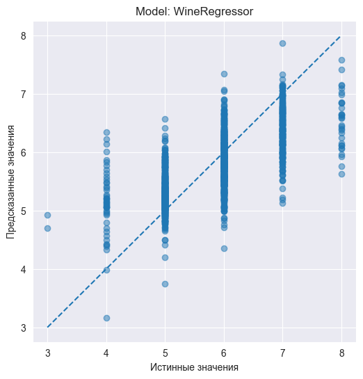

```python
plot_pred_vs_true(y_test, predictions_np, "WineRegressor")
```

```python
def plot_error_histogram(y_true, y_pred, bins=30, label=None):
    errors = [abs(a - b) for a, b in zip(y_true, y_pred)]
    plt.figure(figsize=(6, 4))
    plt.hist(errors, bins=bins, edgecolor='black')
    plt.xlabel("Абсолютная ошибка |ŷ − y|")
    plt.ylabel("Частота")
    plt.title(f"Распределение ошибок{f' ({label})' if label else ''}")
    plt.grid(True)
    plt.show()
```

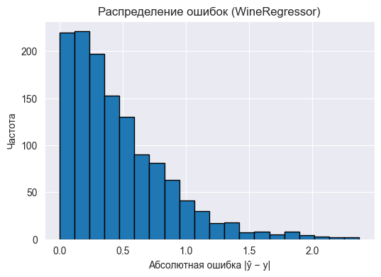

```python
plot_error_histogram(y_test, predictions_np, bins=20, label="WineRegressor")
```

Как можно увидеть на графиках, наша модель имеет довольно сильные разбросы относительно крайних классов, а вот более средние классы, такие как 5, 6, 7 предсказываютя намного лучше.

Так же стоит отметить что наиболее частые предсказания укладываются в ошибку меньше 0.6, что крайне хорошо в задачах с ограниченной шкалой

# Настройка и оптимизация точности модели

### Поиск проблем

Первое, на что стоит обратить внимание, при отпитимизации моделей - это набор данных. Поэтому этим мы и займемся.

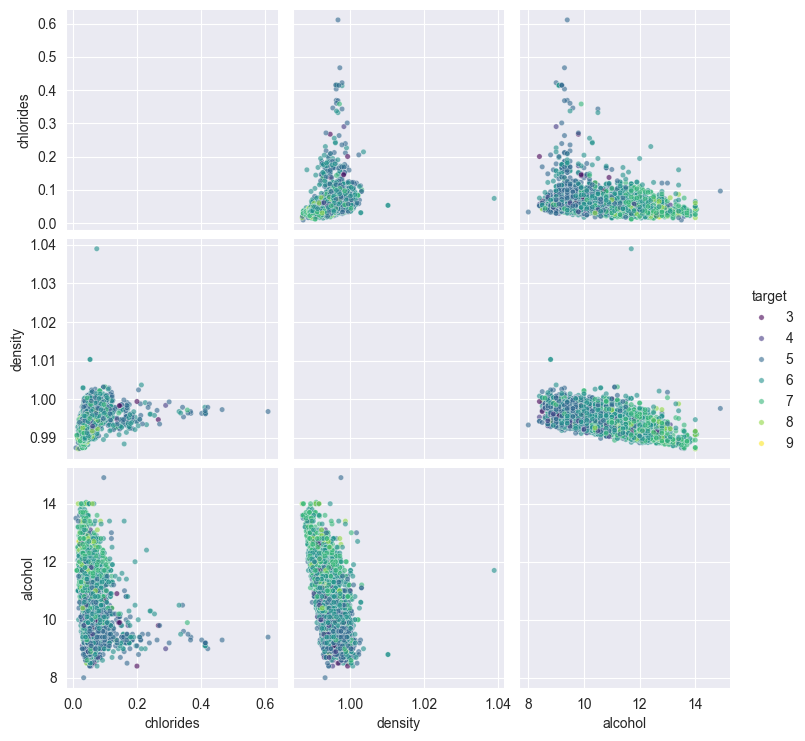

```python
# Сначала посмотрим на рапрелеление признаков
import seaborn as sns
import matplotlib.pyplot as plt

sns.pairplot(
    data=pd.concat([X_train[['chlorides', 'density', 'alcohol']], pd.Series(y_train, name='target')]),
    hue='target',
    palette='viridis',
    diag_kind='hist',
    plot_kws={'alpha': 0.6, 's': 15},
    diag_kws={'bins': 20}
)
plt.show()
```

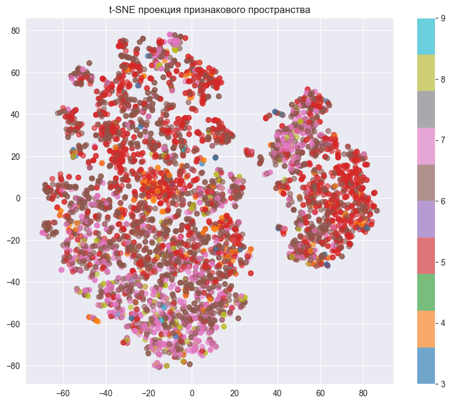

```python
# Также проведем кластерный анализ на предмет разделимости данных на кластера
from sklearn.manifold import TSNE

tsne = TSNE(n_components=2, perplexity=30, random_state=42)
X_tsne = tsne.fit_transform(X_train_scaled)

plt.figure(figsize=(10, 8))
plt.scatter(X_tsne[:, 0], X_tsne[:, 1], c=y_train, cmap='tab10', alpha=0.6)
plt.colorbar()
plt.title('t-SNE проекция признакового пространства')
plt.show()
```

Чтобы попробовать решить данную проблему, можно:

- Попробовать инструменты уменьшения размерности
- Вывести новые фичи и посмотреть, как они будут влиять на таргет-переменную

Эти задачи мы и будем решать далее!

```python
# Также еще интересно посмотреть на баланс таргет-классов
final_wthoutWins_wines['quality'].value_counts()
```

```
quality
6    2836
5    2138
7    1079
4     216
8     193
3      30
9       5
Name: count, dtype: int64
```

Так же хорошей практикой будет:

- Обьединить редкие классы (например 8 и 9 превратить просто в 8 (будет самый максимальный класс из встречаемых)
- Воспользоваться интрументом SMOTE для генерации синтетических данных, чтобы сбалансировать классы таргет-переменной

### Предложения по улучшению модели

### Первое, что стоит можно - это обьединить классы (8+9 и 3+4)

```python
# Код для обьединения редких классов
final_wthoutWins_wines['quality'] = final_wthoutWins_wines['quality'].replace({
    3: 4,
    9: 8
})

# Новое распределение классов
print(final_wthoutWins_wines['quality'].value_counts().sort_index())
```

```
quality
4     246
5    2138
6    2836
7    1079
8     198
Name: count, dtype: int64
```

### Также можно воспользоваться SMOTE, чтобы сгенерировать синтетические данные

```python
# (Используется SMOTENC, чтобы обработать категориальные значения)
from imblearn.over_sampling import SMOTENC

categories = ['wine type_red', 'wine type_white']


def smote_preprocessing_data(categories: list, X_train: pd.DataFrame, y_train: pd.DataFrame):
    cat_features = [X_train.columns.get_loc(col) for col in categories]

    smote_nc = SMOTENC(
        categorical_features=cat_features,
        sampling_strategy='auto',
        random_state=42
    )

    X_train_resampled, y_train_resampled = smote_nc.fit_resample(X_train, y_train)

    # Новое распределение классов
    print(y_train_resampled.value_counts().sort_index())

    return X_train_resampled, y_train_resampled
```

### Можно поработать со структурой и архитектурой нейросетей (возможно стоит вообще пересмотреть испольование нейросетей)

```python
"""
Например можно попробовать обучить модель Классификации
"""


class ResidualBlock(nn.Module):
    def __init__(self, size, dropout=0.3):
        super().__init__()
        self.linear1 = nn.Linear(size, size)  # линейное преобразование
        self.norm1 = nn.LayerNorm(size)  # нормализация слоя, для ускорения и стабилизации обучения
        self.act1 = nn.LeakyReLU(
            negative_slope=0.01)  # функция активации (в отличие от дефолтной Leaky снижает вероятность того, что нейрон "умрет")
        self.dropout = nn.Dropout(
            dropout)  # вид регуляризации, который не дает нейросети полагаться на определенные нейроны, путем выключпения случайных нейронов
        self.linear2 = nn.Linear(size, size)  # линейное преобразование
        self.norm2 = nn.LayerNorm(size)  # нормализация слоя, для ускорения и стабилизации обучения
        self.act2 = nn.LeakyReLU(
            negative_slope=0.01)  # функция активации (в отличие от дефолтной Leaky не дает нейронам "умереть")

    def forward(self, x):
        residual = x
        out = self.linear1(x)
        out = self.norm1(out)
        out = self.act1(out)
        out = self.dropout(out)
        out = self.linear2(out)
        out = self.norm2(out)
        out += residual
        out = self.act2(out)
        return out


# Примерная модель для решения задач классификации
class ImprovedClassifier(nn.Module):
    def __init__(self, input_size, hidden_sizes, output_size, dropout=0.3):
        super().__init__()
        layers = []
        sizes = [input_size] + hidden_sizes
        for i in range(len(sizes) - 1):
            # Слой линейного преобразования из sizes[i] в sizes[i+1]
            layers.append(nn.Linear(sizes[i], sizes[i + 1]))
            # Слой стабилизации и ускорения обучения
            layers.append(nn.BatchNorm1d(sizes[i + 1]))
            # функция активации (говорили о ней в residualblock
            layers.append(nn.LeakyReLU(0.01))
            # регуляцизация (так же было сказано выше в residualblock
            layers.append(nn.Dropout(dropout))

            # Если мы не в самом первом слое, начинаем добовлнять архитектуру слоями residualblock
            if i > 0:
                layers.append(ResidualBlock(sizes[i + 1], dropout=dropout))

        # последний линейный слой для составления нужного выходного размера (количество классов)
        layers.append(nn.Linear(sizes[-1], output_size))

        # Сборка нейросети
        self.net = nn.Sequential(*layers)
        self._initialize_weights()

    def _initialize_weights(self):
        # инициализация для всех линейных слоев
        for m in self.modules():
            if isinstance(m, nn.Linear):
                nn.init.xavier_uniform_(m.weight)
                if m.bias is not None:
                    nn.init.zeros_(m.bias)

    def forward(self, x):
        return self.net(x)
```

Также можно расмотреть ансамблевые алгоритмы, такие как RandomForest или XGBoosting